# 07_Stroud_Likelihood

Hannah Stroud

October 23, 2018

```r
library(readr)
```

```r
library(ggplot2)
library(modelr)
library(dplyr)
library(tidyr)
library(MASS)
```

## 1. Grid Sampling! Load up the pufferfish data and use grid sampling to find the MLE of the slope, intercept and residual SD of this model. Feel free to eyeball results from an lm() fit to get reasonable values. Try not to do this for a grid of more than ~100K points (more if you want!). It’s ok to be coarse. Compare to lm.

```r
puff <-read_csv("./Data/16q11PufferfishMimicry Caley & Schluter 2003.csv")
#coarse scale lm
summary(lm(puff$predators~puff$resemblance))
```

```
##
## Call:
## lm(formula = puff$predators ~ puff$resemblance)
##
## Residuals:
##     Min      1Q  Median      3Q     Max
## -4.9142 -2.1563  0.0858  1.5884  6.0858
##
## Coefficients:
##                  Estimate Std. Error t value Pr(>|t|)
## (Intercept)        1.9247     1.5064   1.278    0.218
## puff$resemblance   2.9895     0.5714   5.232 5.64e-05 ***
## ---
## Signif. codes:  0 '***' 0.001 '**' 0.01 '*' 0.05 '.' 0.1 ' ' 1
##
## Residual standard error: 3.053 on 18 degrees of freedom
## Multiple R-squared:  0.6033, Adjusted R-squared:  0.5812
## F-statistic: 27.37 on 1 and 18 DF,  p-value: 5.638e-05
```

```r
 #build function
lhood_func  <- function(slope, inter, r_sd) {
  #data gen process (mx +b where x=resemblance)
  pred_fit <- inter + slope* puff$resemblance

  #likelihood
  sum(dnorm(puff$predators, pred_fit , r_sd, log=TRUE ))
}
 #grid sample
puff_grid <- crossing(slope= seq(2.5, 3.5, 0.05),
                      inter= seq(0.5, 4, 0.05),
                      r_sd=seq(2.9, 3.1, 0.01)) %>%
  rowwise() %>%
  mutate(logl= lhood_func(slope, inter, r_sd))%>%
  ungroup()
puff_grid%>% filter(logl== max(logl))
```

```
## # A tibble: 1 x 4
##   slope inter  r_sd  logl
##   <dbl> <dbl> <dbl> <dbl>
## 1     3   1.9   2.9 -49.6
```

Compared to lm, our grid sampling values are pretty similar.  
## 2. Surfaces! Filter the dataset to the MLE of the SD. Plot the surface for the slope and intercept in whatever way you find most compelling. You might want to play around with zooming in to different regions, etc. Have fun!

```r
library(viridis)
```

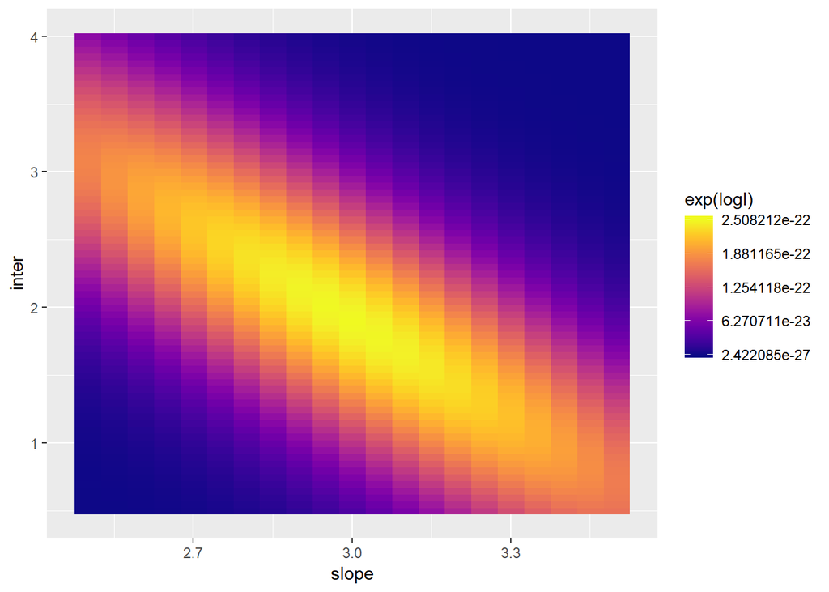

```r
sd_plot <- puff_grid%>% filter(r_sd== max(r_sd))

ggplot(data=sd_plot, aes(x=slope, y=inter, fill= exp(logl))) +
  geom_raster()+
  scale_fill_viridis(option="C")
```

## 3. GLM! Now, compare those results to results from glm. Show the profiles and confidence intervals from glm() for the slope and intercept.

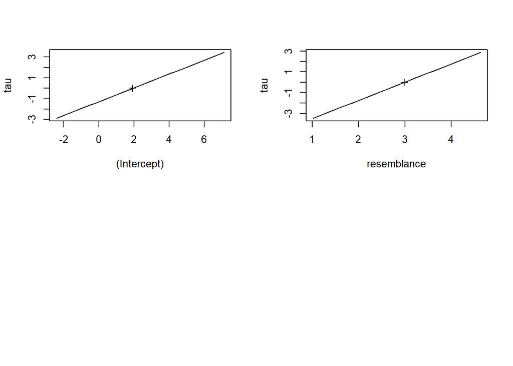

```r
puff_mle <- glm(predators~resemblance,
    family= gaussian(link= "identity"),
    data=puff)

puf_prof <- profile(puff_mle)
plot(puf_prof)   #nice straight lines
```

```r
library(profileModel)
puf_prof_mod<- profileModel(puff_mle,
                             objective= "ordinaryDeviance",
                             quantile= qchisq(0.95,1))
```

```
## Preliminary iteration .. Done
##
## Profiling for parameter (Intercept) ... Done
## Profiling for parameter resemblance ... Done
```

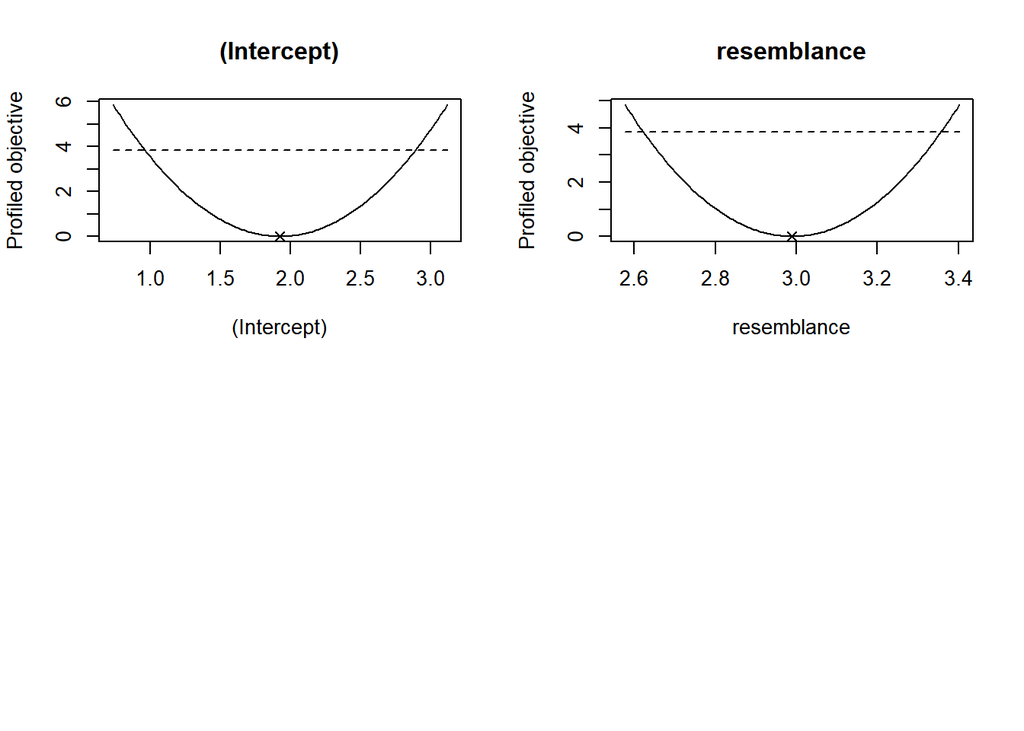

```r
plot(puf_prof_mod)
```

```r
#yay parabolas!
confint(puf_prof)
```

```
##                 2.5 %   97.5 %
## (Intercept) -1.027828 4.877215
## resemblance  1.869537 4.109447
```

## 4. Get Outside of GLM!There are a variety of optimizers out there, and packages for accessing them. One of the best is bbmle by Ecologist Ben Bolker

```r
#load bbmle and try out mle2
library(bbmle)
```

```r
#rewrite likelihood funct to return negative loglikelihood
min_ll <-  function(slope, inter, r_sd){ -1*lhood_func(slope, inter, r_sd)}

#mle2 start with values close to actual estimates
puff_mle2 <- mle2(min_ll,
                  start= list(slope=2.5, inter = 1.5, r_sd=3 ))

#look at summary and plot the profile
summary(puff_mle2)
```

```
## Maximum likelihood estimation
##
## Call:
## mle2(minuslogl = min_ll, start = list(slope = 2.5, inter = 1.5,
##     r_sd = 3))
##
## Coefficients:
##       Estimate Std. Error z value     Pr(z)
## slope  2.98944    0.54209  5.5146 3.495e-08 ***
## inter  1.92486    1.42911  1.3469     0.178
## r_sd   2.89652    0.45798  6.3246 2.540e-10 ***
## ---
## Signif. codes:  0 '***' 0.001 '**' 0.01 '*' 0.05 '.' 0.1 ' ' 1
##
## -2 log L: 99.29798
```

```r
puf_mod2 <- profile(puff_mle2)
```

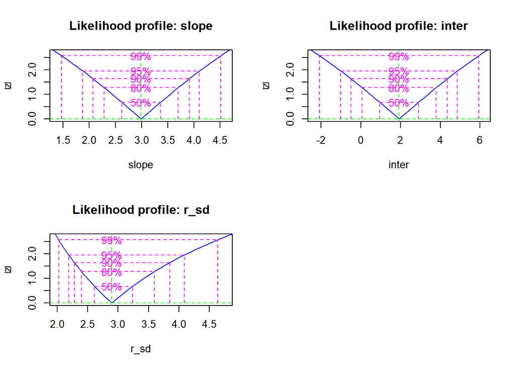

```r
plot(puf_mod2)
```

## 5. Start values! What happens if you start with start values very far away from the initial values. Failing here is fine. But what do you think is happening, and what does this say about the value of start values?

```r
bad_start <- mle2(min_ll,
                  start= list(slope=85, inter = -50, r_sd=0.05 ))
```

```r
#look at summary and plot the profile
summary(bad_start)
```

```
## Maximum likelihood estimation
##
## Call:
## mle2(minuslogl = min_ll, start = list(slope = 85, inter = -50,
##     r_sd = 0.05))
##
## Coefficients:
##       Estimate Std. Error z value   Pr(z)
## slope   25.218     11.186  2.2544 0.02417 *
## inter  -61.023     27.862 -2.1902 0.02851 *
## r_sd    77.892         NA      NA      NA
## ---
## Signif. codes:  0 '***' 0.001 '**' 0.01 '*' 0.05 '.' 0.1 ' ' 1
##
## -2 log L: 213.7015
```

```r
#puf_mod2 <- profile(bad_start)
```

We are so far out of range that it isn’t picking up where our values converge. I got a Hessian error- hash-tagged it out so I could knit into html.

## 6. Algorithms! By default, mle2 uses the Nelder-Mead algorithm via the optim function. What happens if you add an method argument to “SANN” or “L-BFGS-B” (and for the later, which is bounded sampling, give it a lower argument for your residual value, so it’s always positive). See ?optim for some more guidance. Do these both converge to the same value? Based on their profiles, do you trust them?

```r
puff_SANN <- mle2(min_ll,
                  start= list(slope=2.5, inter = 1.5, r_sd=3 ), method= "SANN")
summary(puff_SANN)
```

```
## Maximum likelihood estimation
##
## Call:
## mle2(minuslogl = min_ll, start = list(slope = 2.5, inter = 1.5,
##     r_sd = 3), method = "SANN")
##
## Coefficients:
##       Estimate Std. Error z value     Pr(z)
## slope  2.94948    0.53588  5.5040 3.714e-08 ***
## inter  2.02777    1.41272  1.4354    0.1512
## r_sd   2.86257    0.44475  6.4363 1.224e-10 ***
## ---
## Signif. codes:  0 '***' 0.001 '**' 0.01 '*' 0.05 '.' 0.1 ' ' 1
##
## -2 log L: 99.30936
```

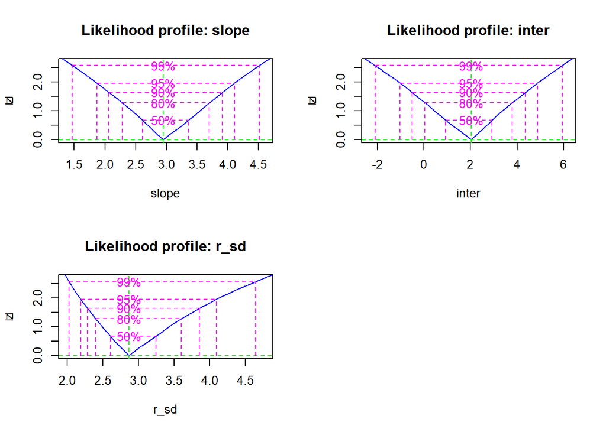

```r
plot(profile(puff_SANN))
```

```r
puff_LBFGS <- mle2(min_ll,
                  start= list(slope=2.5, inter = 1.5, r_sd=2.8 ), method= "L-BFGS-B")
summary(puff_LBFGS)
```

```
## Maximum likelihood estimation
##
## Call:
## mle2(minuslogl = min_ll, start = list(slope = 2.5, inter = 1.5,
##     r_sd = 2.8), method = "L-BFGS-B")
##
## Coefficients:
##       Estimate Std. Error z value     Pr(z)
## slope  2.98949    0.54209  5.5147 3.493e-08 ***
## inter  1.92470    1.42911  1.3468    0.1781
## r_sd   2.89652    0.45798  6.3246 2.540e-10 ***
## ---
## Signif. codes:  0 '***' 0.001 '**' 0.01 '*' 0.05 '.' 0.1 ' ' 1
##
## -2 log L: 99.29798
```

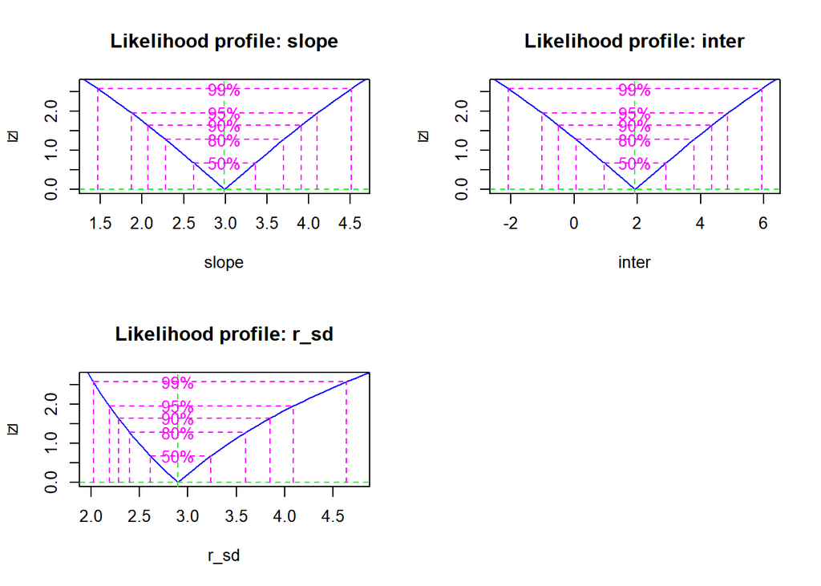

```r
plot(profile(puff_LBFGS))
```